# DV_FinalProject

Probe, Yudkin, Honganen

Wednesday, May 13, 2015

## **Load Packages and Data**

```r
source("../01 Data/Load_Packages.R", echo = TRUE)
```

```
##
## > library("bitops")
##
## > library("RCurl")
##
## > library("ggplot2")
##
## > library("plyr")
##
## > library("tidyr")
##
## > library("dplyr")
```

```
##
## > library("jsonlite")
```

```
##
## > require(EDAWR)
```

```
##
## > require(grid)
```

```r
source("../01 Data/Load_MBS1.R", echo = TRUE)
```

```
##
## > MBS1 <- data.frame(eval(parse(text = substring(getURL(URLencode("http://129.152.144.84:5001/rest/native/?query=\"select * from MBS order by id\""),  .... [TRUNCATED]
```

```r
source("../01 Data/Load_MBS2.R", echo = TRUE)
```

```
##
## > MBS2 <- data.frame(eval(parse(text = substring(getURL(URLencode("http://129.152.144.84:5001/rest/native/?query=\"select * from MBS2 order by id\""), .... [TRUNCATED]
```

```r
source("../01 Data/Load_UNEMPLOYMENT.R", echo = TRUE)
```

```
##
## > UNEMPLOYMENT <- data.frame(eval(parse(text = substring(getURL(URLencode("http://129.152.144.84:5001/rest/native/?query=\"select * from UNEMPLOYMENT  .... [TRUNCATED]
```

```r
MBSALL <- bind_rows(MBS1, MBS2)
tbl_df(MBSALL)
```

```
## Source: local data frame [7,400 x 10]
##
##    ID   LTV   CLTV ORIG_BAL ORIG_TERM ORIG_RATE STATE FICO OCCUPANCY TYPE
## 1   1 80.00 100.00   375200       360      8.50    CA  624        OO  ARM
## 2   2 80.00 100.00   380000       480      6.99    NY  648        OO  ARM
## 3   3 90.00  90.00    61200       360      8.75    IN  630        IO  Fix
## 4   4 20.00 100.00    52000       360     11.90    IL  616        OO  Fix
## 5   5 80.00 100.00   156000       360      8.30    IL  690        OO  ARM
## 6   6 89.32  89.32   236700       480      8.98    FL  557        OO  ARM
## 7   7 75.00  75.00   300000       360     10.05    WA  532        OO  ARM
## 8   8 79.31  79.31   115000       360      8.99    NJ  540        OO  ARM
## 9   9 80.00 100.00   236000       480      7.60    FL  627        OO  ARM
## 10 10 85.48  85.48   530000       360      6.20    CA  704        OO  Fix
## .. ..   ...    ...      ...       ...       ...   ...  ...       ...  ...
```

## **Data Sets**

### Mortgage Backed Security # 1

```r
tbl_df(MBS1)
```

```
## Source: local data frame [4,906 x 10]
##
##    ID   LTV   CLTV ORIG_BAL ORIG_TERM ORIG_RATE STATE FICO OCCUPANCY TYPE
## 1   1 80.00 100.00   375200       360      8.50    CA  624        OO  ARM
## 2   2 80.00 100.00   380000       480      6.99    NY  648        OO  ARM
## 3   3 90.00  90.00    61200       360      8.75    IN  630        IO  Fix
## 4   4 20.00 100.00    52000       360     11.90    IL  616        OO  Fix
## 5   5 80.00 100.00   156000       360      8.30    IL  690        OO  ARM
## 6   6 89.32  89.32   236700       480      8.98    FL  557        OO  ARM
## 7   7 75.00  75.00   300000       360     10.05    WA  532        OO  ARM
## 8   8 79.31  79.31   115000       360      8.99    NJ  540        OO  ARM
## 9   9 80.00 100.00   236000       480      7.60    FL  627        OO  ARM
## 10 10 85.48  85.48   530000       360      6.20    CA  704        OO  Fix
## .. ..   ...    ...      ...       ...       ...   ...  ...       ...  ...
```

### Mortgage Backed Security # 2

```r
tbl_df(MBS2)
```

```
## Source: local data frame [2,494 x 10]
##
##    ID  LTV CLTV ORIG_BAL ORIG_TERM ORIG_RATE STATE FICO OCCUPANCY TYPE
## 1   1 90.0 90.0   145800       360     8.875    WI  704        IO  Fix
## 2   2 95.0 95.0   266004       360     9.125    NC  643        OO  ARM
## 3   3 90.0 90.0   290723       360     7.250    AZ  701        OO  ARM
## 4   4 71.2 71.2   178000       360     8.375    AZ  697        OO  ARM
## 5   5 80.0 80.0    89600       360     8.500    TX  653        OO  ARM
## 6   6 90.0 90.0   198000       360     7.875    ME  654        SH  ARM
## 7   7 95.0 95.0   228000       360     7.875    LA  654        OO  ARM
## 8   8 95.0 95.0   185250       360     8.750    MN  661        OO  ARM
## 9   9 85.0 85.0   219512       360     7.875    NC  633        OO  ARM
## 10 10 95.0 95.0   137750       360     8.500    OH  653        OO  Fix
## .. ..  ...  ...      ...       ...       ...   ...  ...       ...  ...
```

### Unemployment Data

```r
tbl_df(UNEMPLOYMENT)
```

```
## Source: local data frame [52 x 2]
##
##    STATE RATE
## 1     AK  6.1
## 2     AL  3.4
## 3     AR  5.3
## 4     AZ  3.7
## 5     CA  5.4
## 6     CO  3.8
## 7     CT  4.6
## 8     DC  5.5
## 9     DE  3.5
## 10    FL  4.0
## ..   ...  ...
```

### Statistics about our data

```r
source("../03 Visualizations/Categorical.R", echo = TRUE)
```

```
##
## > categoricals <- eval(parse(text = substring(getURL(URLencode("http://129.152.144.84:5001/rest/native/?query=\"select * from MBS\""),
## +     httphead .... [TRUNCATED]
##
## > l <- list()
##
## > for (i in names(MBSALL)) {
## +     if (i %in% categoricals[[1]]) {
## +         r <- data.frame(fromJSON(getURL(URLencode("129.152.144.84:5001/rest/nativ ..." ... [TRUNCATED]
```

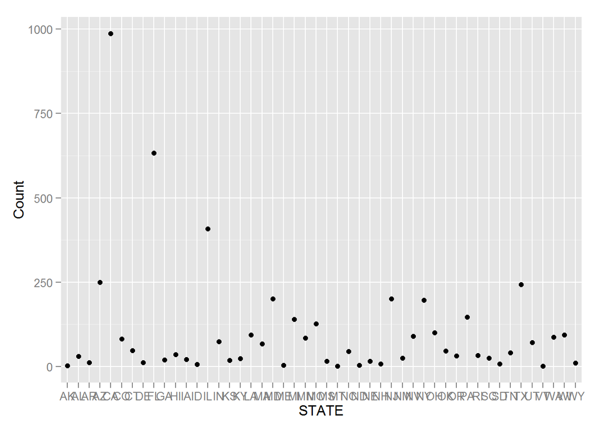

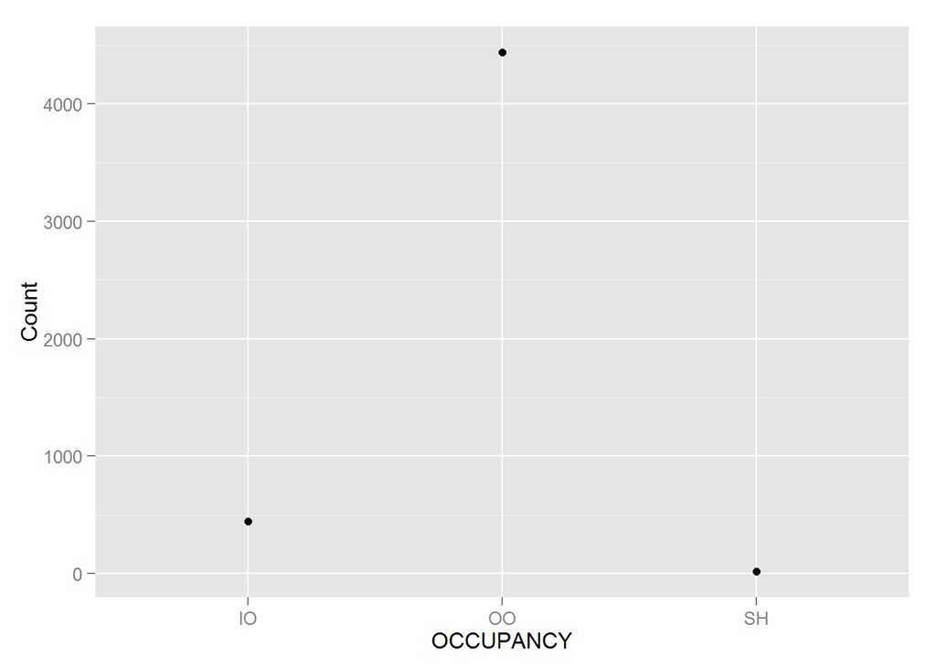

```
##
## > png("../00 Doc/categoricals.png", width = 25, height = 10,
## +     units = "in", res = 72)
##
## > grid.newpage()
```

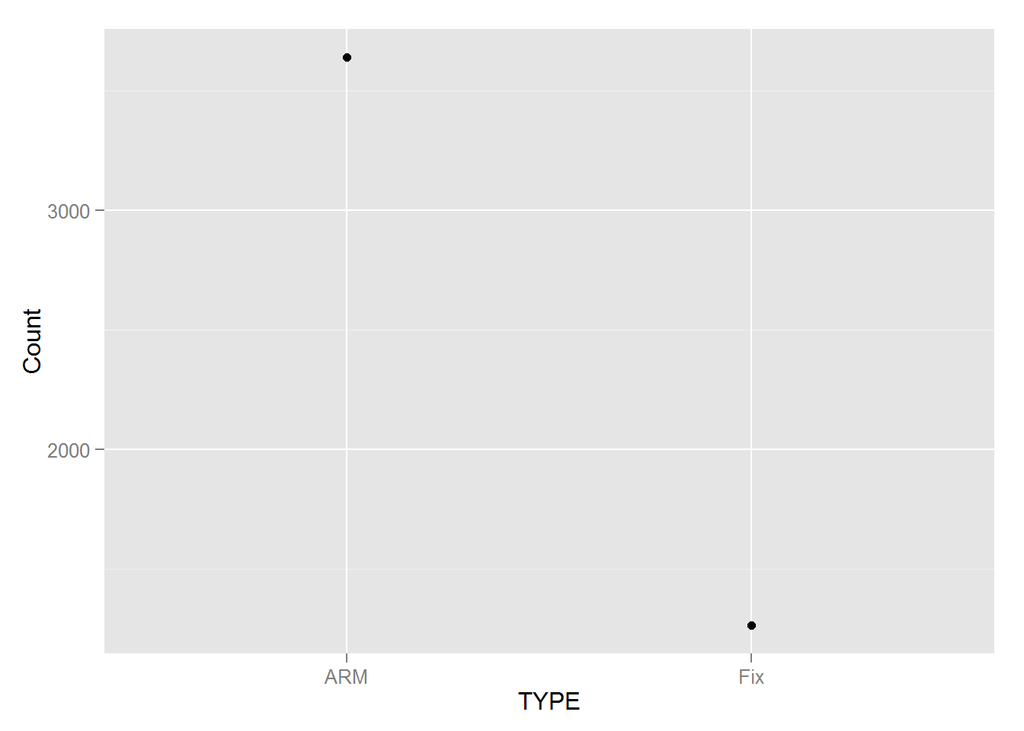

```
##
## > pushViewport(viewport(layout = grid.layout(1, 12)))
##
## > print(l[[1]], vp = viewport(layout.pos.row = 1, layout.pos.col = 1:4))
##
## > print(l[[2]], vp = viewport(layout.pos.row = 1, layout.pos.col = 5:8))
##
## > print(l[[3]], vp = viewport(layout.pos.row = 1, layout.pos.col = 9:12))
##
## > dev.off()
## png
##   2
##
## > l <- list()
##
## > for (i in names(MBSALL)) {
## +     if (i %in% categoricals[[2]] & i != "ID") {
## +         r <- data.frame(fromJSON(getURL(URLencode("129.152.144.84:500 ..." ... [TRUNCATED]
```

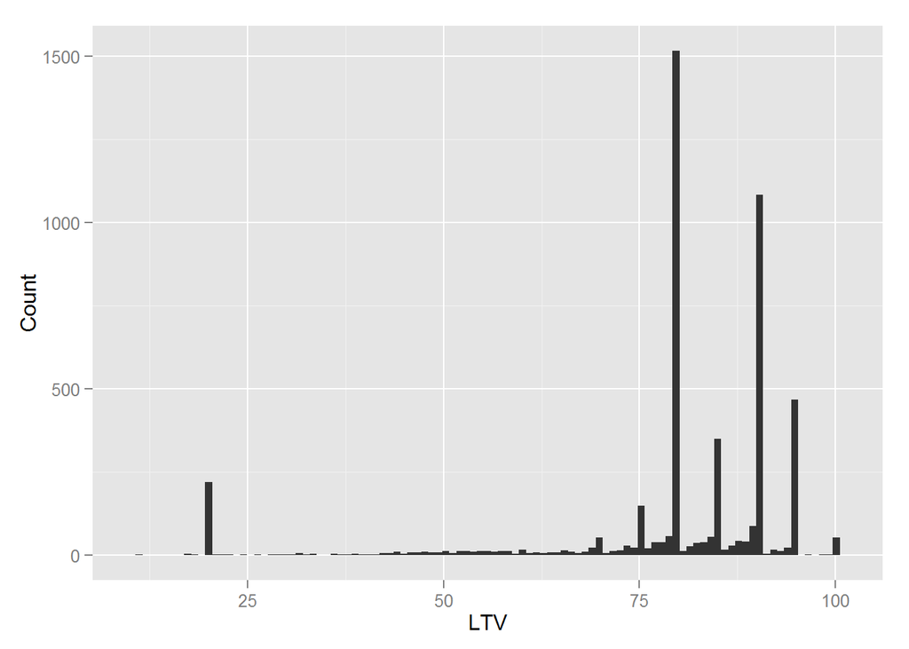

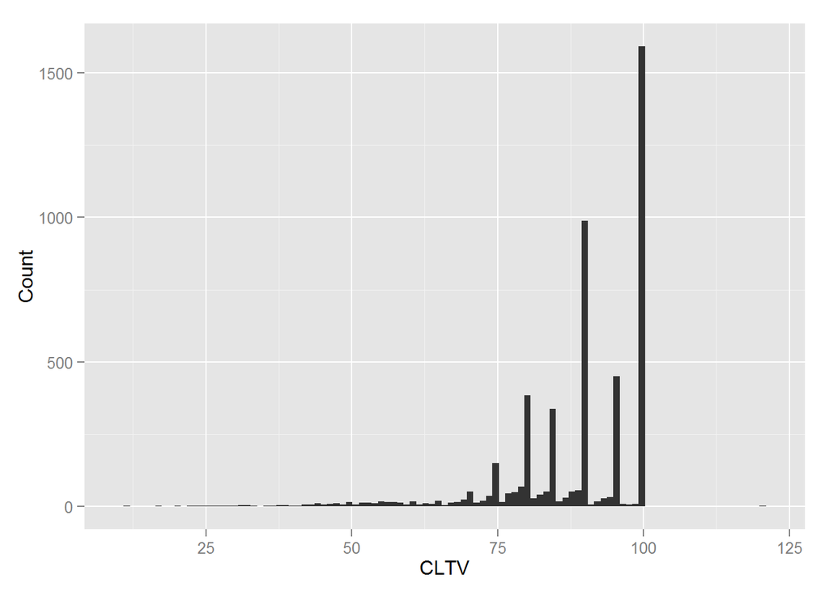

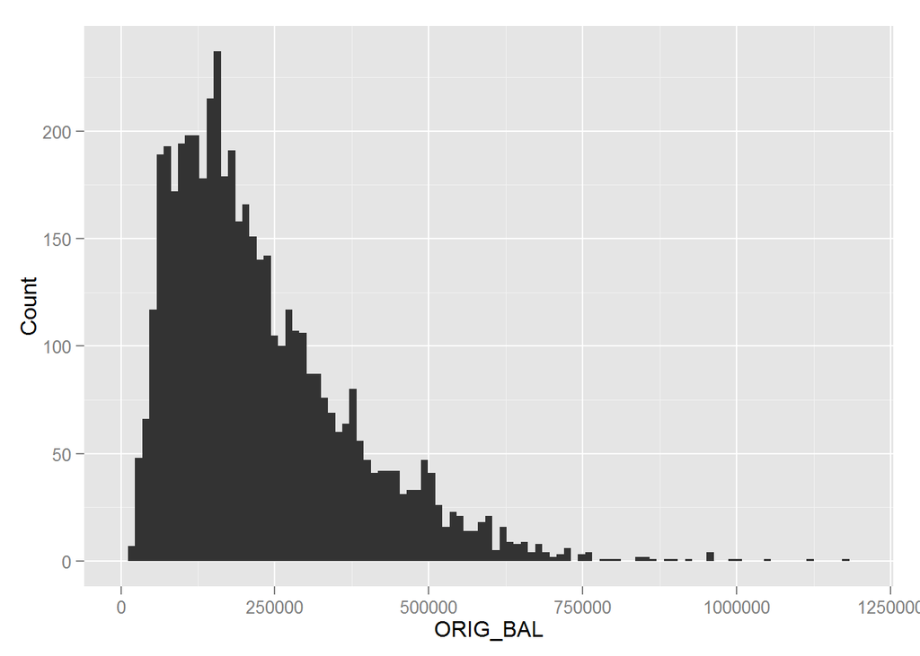

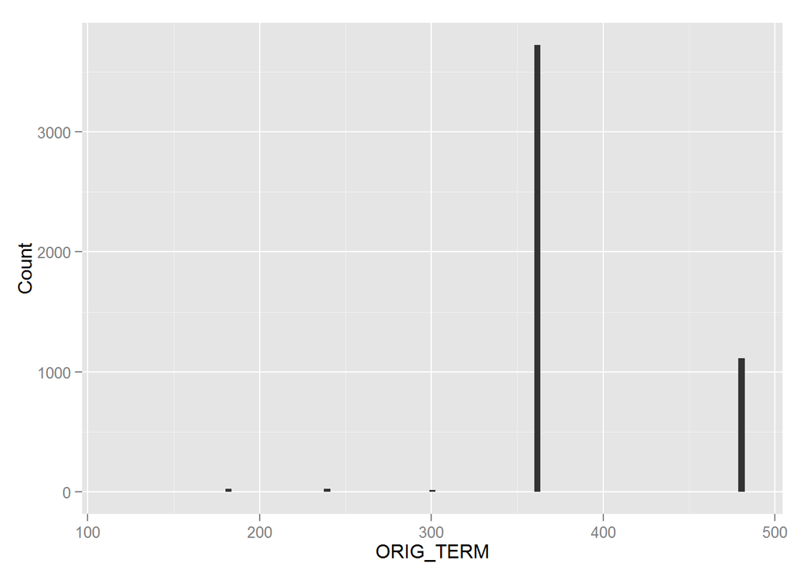

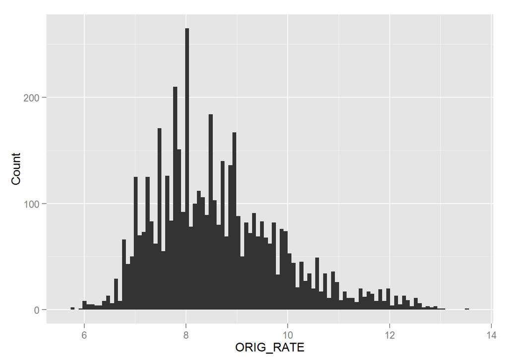

```
##
## > png("../00 Doc/categoricals2.png", width = 40, height = 20,
## +     units = "in", res = 72)
##
## > grid.newpage()
```

```
##
## > pushViewport(viewport(layout = grid.layout(2, 28)))
##
## > print(l[[1]], vp = viewport(layout.pos.row = 1, layout.pos.col = 1:7))
##
## > print(l[[2]], vp = viewport(layout.pos.row = 1, layout.pos.col = 8:14))
```

```
##
## > print(l[[3]], vp = viewport(layout.pos.row = 1, layout.pos.col = 15:21))
##
## > print(l[[4]], vp = viewport(layout.pos.row = 1, layout.pos.col = 22:28))
```

```
##
## > print(l[[5]], vp = viewport(layout.pos.row = 2, layout.pos.col = 1:7))
##
## > print(l[[6]], vp = viewport(layout.pos.row = 2, layout.pos.col = 8:14))
```

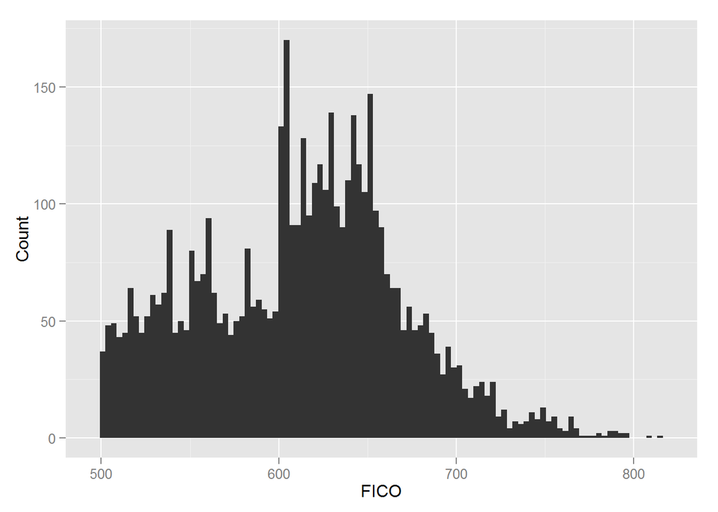

```
##
## > dev.off()
## png
##   2
```

### Chart 1

This chart combines the two mortgage backed securities and shows the amount of loans by type. “Fix”" signifies a fixed rate loan and “ARM”" signifies an adjustable rate mortgate.

```r
source("../02 Data Wrangling/DataWrangling1 - chart.R", echo = TRUE)
```

```
##
## > MBSALL %>% group_by(TYPE) %>% summarise(COUNT = n())
## Source: local data frame [2 x 2]
##
##   TYPE COUNT
## 1  ARM  5381
## 2  Fix  2019
```

```r
source("../03 Visualizations/DataWrangling1 - visualization.R", echo = TRUE)
```

```
##
## > MBSALL %>% group_by(TYPE) %>% summarise(COUNT = n()) %>%
## +     ggplot(aes(x = TYPE, y = COUNT, fill = TYPE)) + geom_bar(stat = "identity")
```

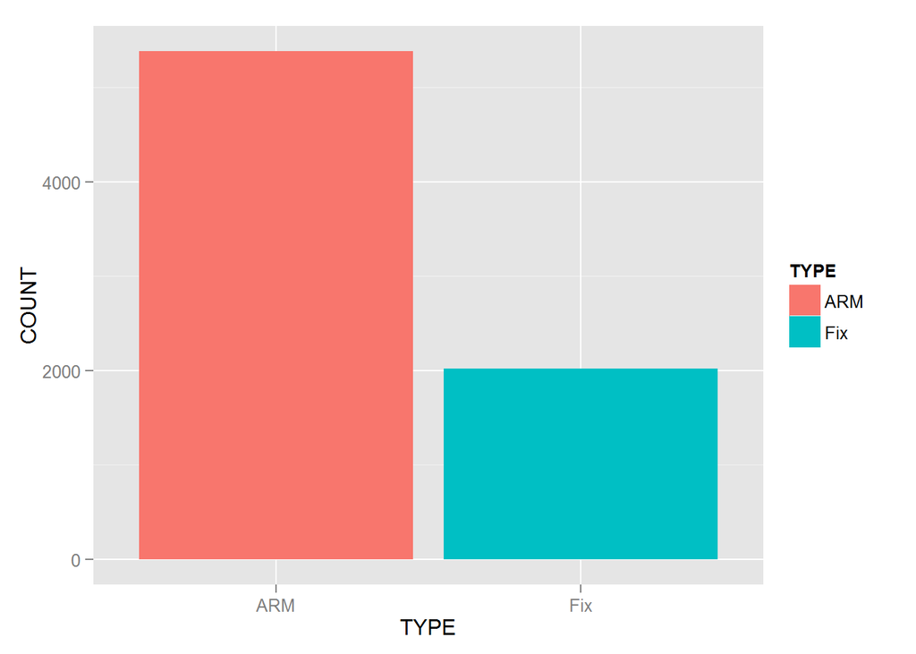

```r
MBSALL <- bind_rows(MBS1, MBS2)
```

### Chart 2

This chart combines the two mortgage backed securities and filters the loans for Texas and California, provides a summary and then charts FICO vs. Orig_Rate

```r
source("../02 Data Wrangling/DataWrangling2 - chart.R", echo = TRUE)
```

```
##
## > MBSALL %>% filter(STATE == "TX" | STATE == "CA") %>%
## +     group_by(OCCUPANCY) %>% summarise(Count = n(), min(FICO),
## +     max(FICO), mean(FICO),  .... [TRUNCATED]
## Source: local data frame [3 x 8]
##
##   OCCUPANCY Count min(FICO) max(FICO) mean(FICO) min(CLTV) max(CLTV)
## 1        IO   104       532       814   664.9038     28.20       100
## 2        OO  1534       500       796   628.0606     10.99       100
## 3        SH    15       528       686   640.2667     62.03       100
## Variables not shown: mean(CLTV) (dbl)
```

```r
source("../03 Visualizations/DataWrangling2 - visualization.R", echo = TRUE)
```

```
##
## > MBSALL %>% filter(STATE == "TX" | STATE == "CA") %>%
## +     group_by(OCCUPANCY) %>% ggplot(aes(x = FICO, y = ORIG_RATE,
## +     color = STATE)) + geo .... [TRUNCATED]
```

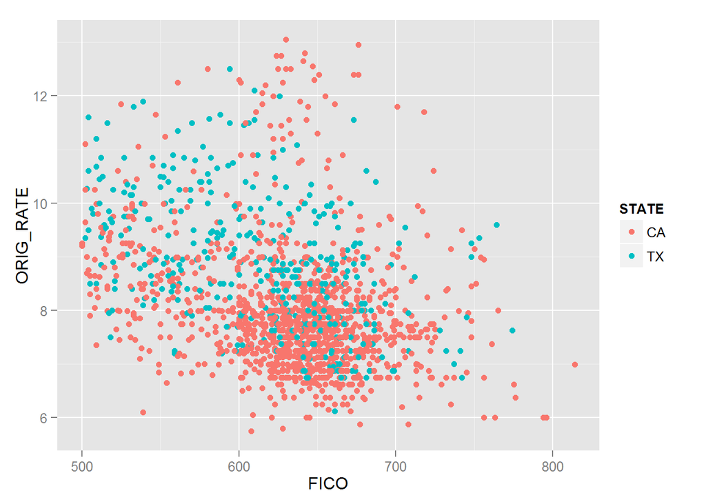

```r
MBSALL <- bind_rows(MBS1, MBS2)
```

### Chart 3

This chart combines the two mortgage backed securities and filters the loans for the top 50% according to the rate and then graphs CLTV vs. Interest Rate

```r
source("../02 Data Wrangling/DataWrangling3 - chart.R", echo = TRUE)
```

```
##
## > MBSALL %>% mutate(RATE_DIST = cume_dist(ORIG_RATE)) %>%
## +     filter(RATE_DIST >= 0.5) %>% arrange(RATE_DIST) %>% select(ID,
## +     LTV, CLTV, ORIG .... [TRUNCATED]
## Source: local data frame [3,797 x 6]
##
##      ID   LTV   CLTV ORIG_RATE FICO RATE_DIST
## 1   246 80.00 100.00     8.125  645 0.5036486
## 2   491 90.00  90.00     8.125  703 0.5036486
## 3   618 58.15  58.15     8.125  620 0.5036486
## 4  1423 84.62  84.62     8.125  521 0.5036486
## 5  2125 93.86  93.86     8.125  735 0.5036486
## 6  2344 66.67  66.67     8.125  553 0.5036486
## 7  2407 89.94  89.94     8.125  655 0.5036486
## 8  2996 85.00  85.00     8.125  605 0.5036486
## 9  3389 90.00  90.00     8.125  663 0.5036486
## 10 3535 54.24  54.24     8.125  619 0.5036486
## ..  ...   ...    ...       ...  ...       ...
```

```r
source("../03 Visualizations/DataWrangling3 - visualization.R", echo = TRUE)
```

```
##
## > MBSALL %>% mutate(RATE_DIST = cume_dist(ORIG_RATE)) %>%
## +     filter(RATE_DIST >= 0.5) %>% arrange(RATE_DIST) %>% select(ID,
## +     LTV, CLTV, ORIG .... [TRUNCATED]
```

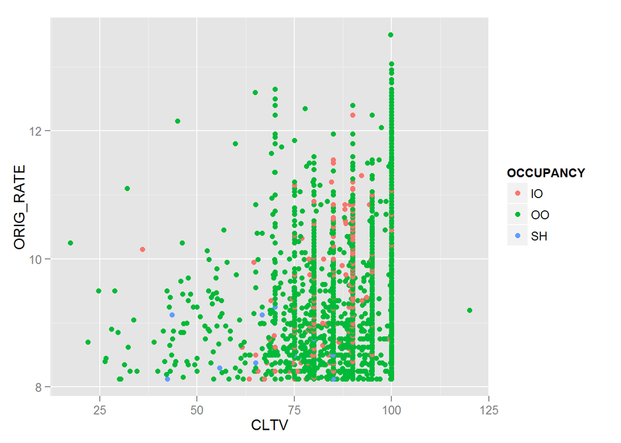

```r
MBSALL <- bind_rows(MBS1, MBS2)
```

### Chart 4

```r
source("../02 Data Wrangling/DataWrangling4 - chart.R", echo = TRUE)
```

```
##
## > names(UNEMPLOYMENT) = c("STATE", "UNEMPLOYMENT_RATE")
##
## > DATA1 <- MBSALL %>% group_by(STATE) %>% summarise(AVG_FICO = mean(FICO)) %>%
## +     inner_join(UNEMPLOYMENT, by = "STATE")
```

```
##
## > tbl_df(DATA1)
## Source: local data frame [51 x 3]
##
##    STATE AVG_FICO UNEMPLOYMENT_RATE
## 1     AK 645.4545               6.1
## 2     AL 624.1186               3.4
## 3     AR 637.8077               5.3
## 4     AZ 619.9054               3.7
## 5     CA 635.4520               5.4
## 6     CO 635.3741               3.8
## 7     CT 633.8714               4.6
## 8     DC 642.2667               5.5
## 9     DE 640.8537               3.5
## 10    FL 626.5929               4.0
## ..   ...      ...               ...
```

```r
source("../03 Visualizations/DataWrangling4 - visualization.R", echo = TRUE)
```

```
##
## > VIS1 <- DATA1 %>% ggplot(aes(x = UNEMPLOYMENT_RATE,
## +     y = AVG_FICO)) + geom_point(aes(color = STATE)) + geom_text(aes(label = STATE,
## +     hju .... [TRUNCATED]
##
## > VIS1 <- VIS1 + ggtitle("Unemployment Rate vs. Fico Score") +
## +     theme(plot.title = element_text(size = 18, face = "bold",
## +         vjust = 2))
##
## > VIS1 <- VIS1 + labs(x = "Unemployment Rate (%)", y = paste("FICO Score")) +
## +     theme(axis.title.x = element_text(face = "bold", vjust = 0.35),
##  .... [TRUNCATED]
##
## > VIS1 <- VIS1 + theme(panel.background = element_rect(fill = "grey92",
## +     color = "grey1")) + theme(legend.position = "none")
##
## > VIS1
```

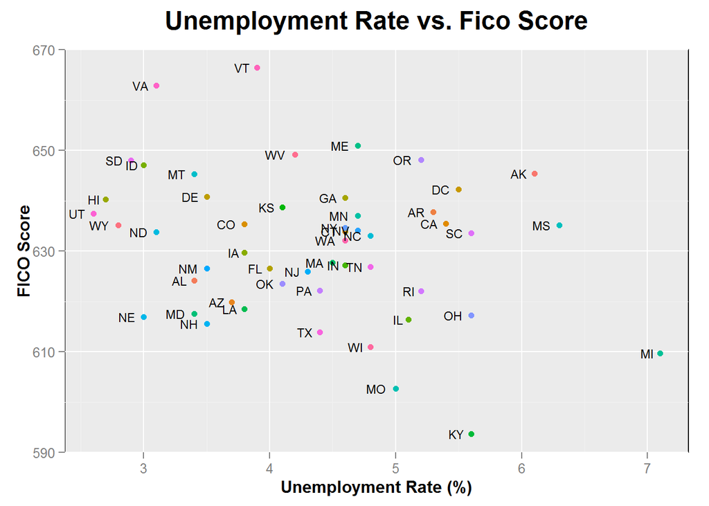

```
##
## > CORR <- cor(DATA1[, 2:3])
##
## > print(paste("Correlation of average state unemployment rate and credit score from our MBS sample is ",
## +     round(CORR[1, 2], digits = 3)))
## [1] "Correlation of average state unemployment rate and credit score from our MBS sample is  -0.25"
```

```r
MBSALL <- bind_rows(MBS1, MBS2)
```

### Chart 5

```r
source("../02 Data Wrangling/DataWrangling5 - chart.R", echo = TRUE)
```

```
##
## > DATA2 <- MBSALL %>% group_by(STATE, OCCUPANCY) %>%
## +     summarise(OCCUPANCY_COUNT = n()) %>% spread(OCCUPANCY, OCCUPANCY_COUNT) %>%
## +     full_jo .... [TRUNCATED]
```

```
##
## > DATA2[is.na(DATA2)] <- 0
##
## > DATA2 <- DATA2 %>% group_by(ABOVE_AVG_UNEMPLOYMENT) %>%
## +     summarise(IO = mean(IO) * n(), OO = mean(OO) * n(), SH = mean(SH) *
## +         n())
##
## > DATA2[1, 1] <- "State Unemployment <= 4.45%"
##
## > DATA2[2, 1] <- "State Unemployment > 4.45%"
##
## > names(DATA2) <- c("ABOVE_AVG_UNEMPLOYMENT", "INVESTOR OWNED",
## +     "OWNER OCCUPIED", "SECOND HOME")
##
## > TDATA2 <- DATA2 %>% gather(ABOVE_AVG_UNEMPLOYMENT,
## +     value, 2, 3, 4)
##
## > names(TDATA2) <- c("ABOVE_AVG_UNEMPLOYMENT", "OCCUPANCY",
## +     "COUNT")
##
## > tbl_df(DATA2)
## Source: local data frame [2 x 4]
##
##        ABOVE_AVG_UNEMPLOYMENT INVESTOR OWNED OWNER OCCUPIED SECOND HOME
## 1 State Unemployment <= 4.45%            364           2904          57
## 2  State Unemployment > 4.45%            413           3623          39
```

```r
source("../03 Visualizations/DataWrangling5 - visualization.R", echo = TRUE)
```

```
##
## > VIS2 <- TDATA2 %>% ggplot(aes(x = OCCUPANCY, y = COUNT,
## +     fill = ABOVE_AVG_UNEMPLOYMENT)) + geom_bar(stat = "identity",
## +     position = "dodg ..." ... [TRUNCATED]
##
## > VIS2 <- VIS2 + ggtitle("Occupancy vs. Avg. Unemployment Rate") +
## +     theme(plot.title = element_text(size = 18, face = "bold",
## +         vjust = .... [TRUNCATED]
##
## > VIS2 <- VIS2 + labs(x = "Occupant Type", y = paste("Count")) +
## +     theme(axis.title.x = element_text(face = "bold", vjust = 0.35),
## +         axi .... [TRUNCATED]
##
## > VIS2
```

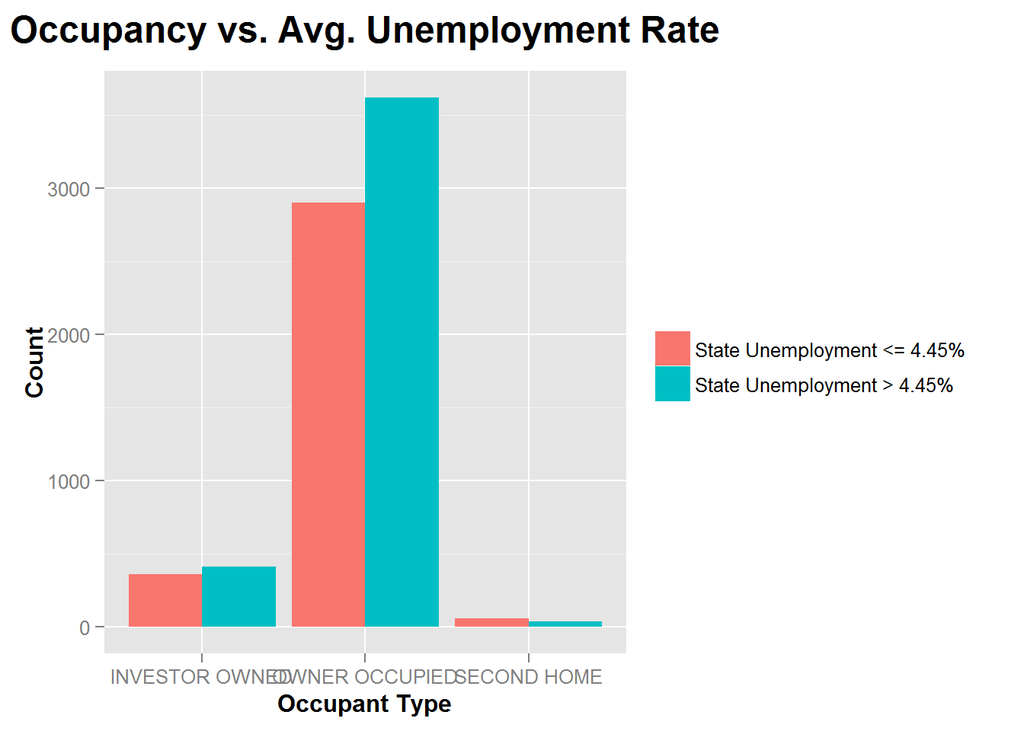

```r
MBSALL <- bind_rows(MBS1, MBS2)
```

### Chart 6

```r
source("../02 Data Wrangling/DataWrangling6 - chart.R", echo = TRUE)
```

```
##
## > DATA3 <- MBSALL %>% mutate(RATE_DIST = cume_dist(ORIG_RATE)) %>%
## +     filter(RATE_DIST >= 0.5) %>% arrange(RATE_DIST) %>% left_join(UNEMPLOYMENT,  .... [TRUNCATED]
```

```r
source("../03 Visualizations/DataWrangling6 - visualization.R", echo = TRUE)
```

```
##
## > VIS3 <- DATA3 %>% ggplot(aes(x = UNEMPLOYMENT_RATE_AVG,
## +     y = INTEREST_RATE_AVG)) + geom_point(aes(color = STATE)) +
## +     geom_text(aes(label .... [TRUNCATED]
##
## > VIS3 <- VIS3 + ggtitle("Unemployment Rate vs. Average Interest Rate") +
## +     theme(plot.title = element_text(size = 18, face = "bold",
## +          .... [TRUNCATED]
##
## > VIS3 <- VIS3 + labs(x = "Unemployment Rate (%)", y = paste(" Average Interest Rate (%)")) +
## +     theme(axis.title.x = element_text(face = "bold",  .... [TRUNCATED]
##
## > VIS3 <- VIS3 + theme(panel.background = element_rect(fill = "grey92",
## +     color = "grey1")) + theme(legend.position = "none")
##
## > VIS3
```

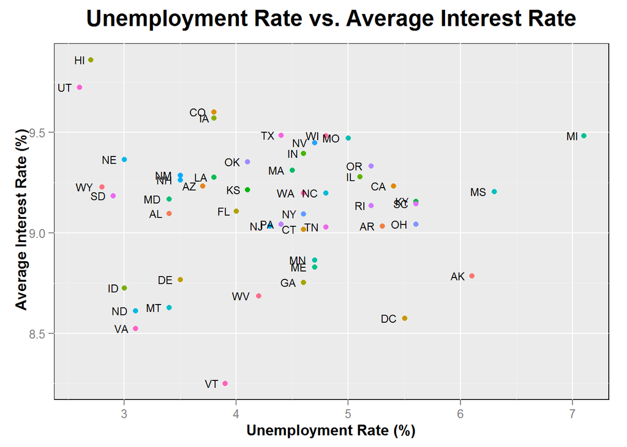

[output not shown]

```r
MBSALL <- bind_rows(MBS1, MBS2)
```

### Tableau Vis 1 - AVG FICO by State for both MBS #1 and MBS #2

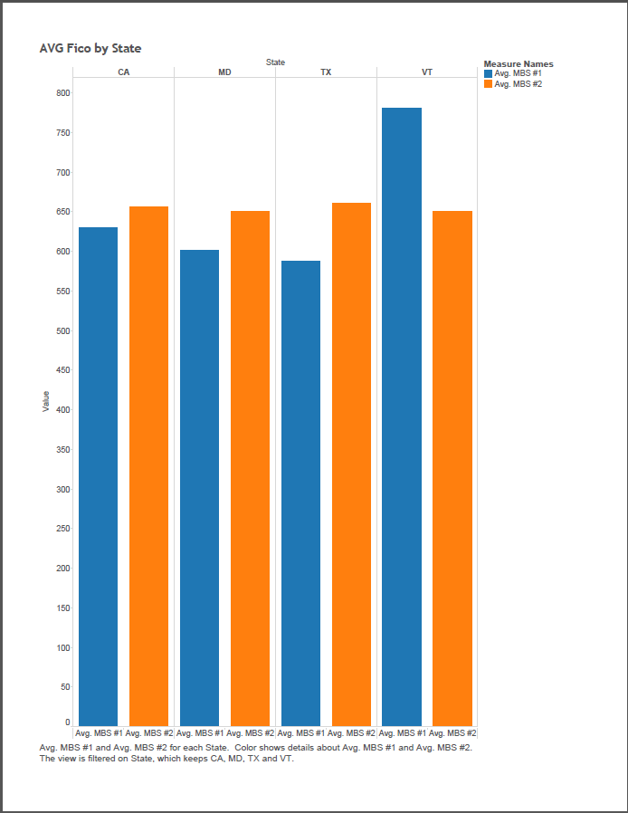

### Tableau Vis 2 - Interest Rate V. Unemployment Rate by State

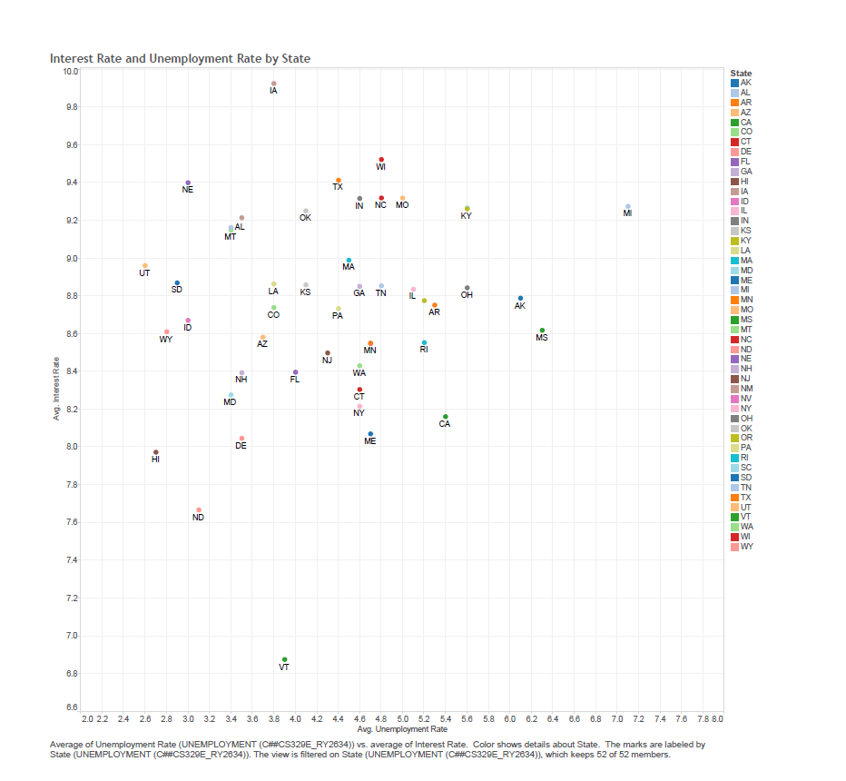

### Tableau Vis 3 - AVG CLTV by State for both MBS #1 and MBS #2

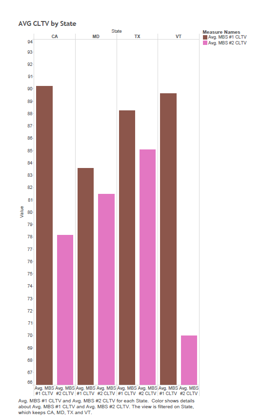

### Tableau Vis 4 - FICO V. Unemployment Rate by State

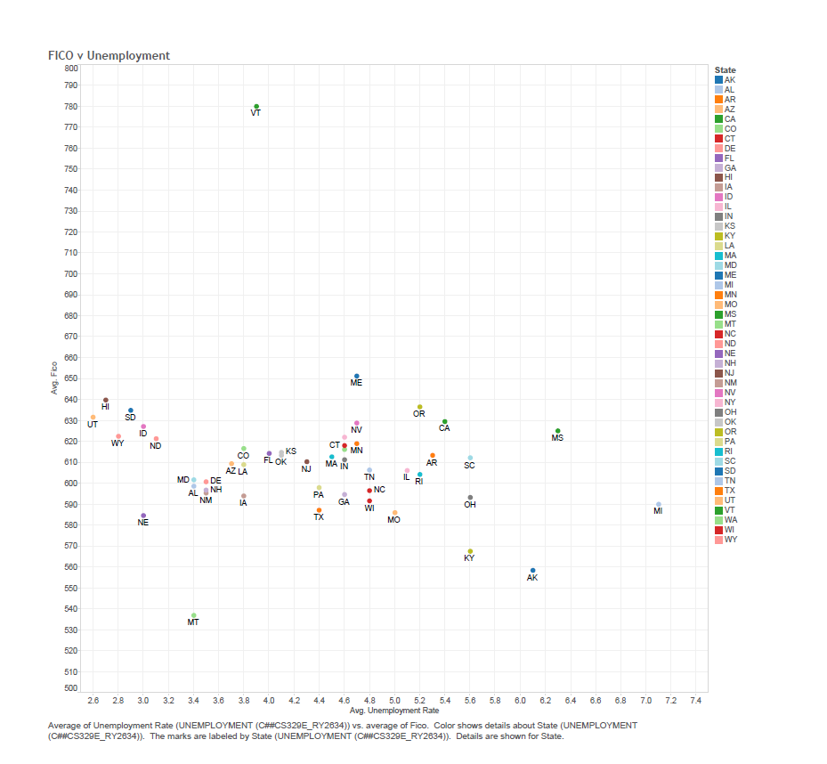

### Thanks for a great semester, Dr. Cannata!!!